# Python × 資料分析

## Scikit-Learn

## Kristen Chan

# Agenda

- Introduction
- Datasets
- Train data ＆ Test data
- Data Preprocessing
- Machine Learning Algorithms
  - Supervised learning
    - Regression -- Linear Regression
    - Regression -- Support Vector Regression
    - Classification -- Logistic Regression
    - Classification -- K-Nearest Neighbors
    - Classification -- Support Vector Machine
  - Unsupervised learning
    - Clustering -- K-means
    - Clustering -- Hierarchical clustering

# Review

[figure not shown]

> Reference : https://www.wikiwand.com/en/Data_analysis

# Note

```python
import numpy as np
import pandas as pd
import matplotlib.pyplot as plt
import seaborn as sns
%matplotlib inline
```

# Scikit-Learn

### Introduction

# Introduction

- 資料探勘 and 機器學習
- 建立在 NumPy, SciPy ,Matplotlib 套件上
- 六大功能：  
  a. Preprocessing (資料預處理)  
  b. Dimensionality reduction (資料降維)  
  c. Regression (迴歸)  
  d. Classification (分類)  
  e. Clustering (分群)  
  f. Model selection (模型評估/選取)

# Introduction

# Note

- Supervised learning
  - Regression
  - Classification
- Unsupervised learning
  - Clustering

# Introduction

- Machine Learning Problem：

[figure not shown]

  > Reference : http://scikit-learn.org/stable/tutorial/machine_learning_map/

# Introduction

# Note

SciKits

> Reference : https://scikits.appspot.com/scikits

# Scikit-Learn

### Datasets

# Datasets

- Boston
- Iris

# Datasets

# Note

- Scikit-Learn 針對不同資料集使用不同的 load 指令
- 格式：

  ```
  load_資料集名稱()
  ```

# Datasets -- Boston

- Import Scikit-Learn 的 Datasets

```python
from sklearn import datasets
```

- Dataset (boston)

```python
boston = datasets.load_boston()
```

# Datasets -- Boston

- Check boston (type)

```python
type(boston)
```

```
sklearn.utils.Bunch
```

> The Bunch object in Scikit-Learn is simply a dictionary that exposes dictionary keys as properties so that you can access them with dot notation.

# Datasets -- Boston

- Check boston (key)

```python
boston.keys()
```

```
dict_keys(['data', 'target', 'feature_names', 'DESCR'])
```

> - data：解釋變數
> - target：反應變數
> - feature_names：變數名稱說明
> - DESCR：資料描述

# Datasets -- Boston

- boston (DESCR)

```python
boston.DESCR
```

```
"Boston House Prices dataset\n===========================\n\nNotes\n------\nData Set Characteristics:  \n\n    :Number of Instances: 506 \n\n    :Number of Attributes: 13 numeric/categorical predictive\n    \n    :Median Value (attribute 14) is usually the target\n\n    :Attribute Information (in or…
```

# Datasets -- Boston

- boston ( feature_names )

```python
boston.feature_names
```

```
array(['CRIM', 'ZN', 'INDUS', 'CHAS', 'NOX', 'RM', 'AGE', 'DIS', 'RAD',
       'TAX', 'PTRATIO', 'B', 'LSTAT'],
      dtype='<U7')
```

> 分别是房屋均價及周邊犯罪率、是否在河邊等相關信息

# Datasets -- Boston

- 確認 boston ( data ) 的維度

```python
boston.data.shape
```

```
(506, 13)
```

- 確認 boston ( target ) 的維度

```python
boston.target.shape
```

```
(506,)
```

# Datasets -- Iris

- Import Scikit-Learn 的 Datasets

```python
from sklearn import datasets
```

- Dataset (iris)

```python
iris = datasets.load_iris()
```

> 鳶尾花(iris)資料集是非常著名的生物資訊資料集之一，取自美國加州大學歐文分校的機械學習資料庫

# Datasets -- Iris

- Check iris (key)

```python
iris.keys()
```

```
dict_keys(['data', 'target', 'target_names', 'DESCR', 'feature_names'])
```

> - data：解釋變數
> - target：反應變數
> - target_names：反應變數的類別名稱
> - feature_names：變數名稱說明
> - DESCR：資料描述

# Datasets -- Iris

- iris (DESCR)

```
iris.DESCR
```

[figure not shown]

# Datasets -- Iris

- iris ( target_names )

```python
iris.target_names
```

```
array(['setosa', 'versicolor', 'virginica'],
      dtype='<U10')
```

[figure not shown]

# Datasets -- Iris

- iris ( feature_names )

```python
iris.feature_names
```

```
['sepal length (cm)',
 'sepal width (cm)',
 'petal length (cm)',
 'petal width (cm)']
```

> 分别是花萼、花瓣等相關信息

# Datasets -- Iris

- 確認 iris ( data ) 的維度

```python
iris.data.shape
```

```
(150, 4)
```

- 確認 iris ( target ) 的維度

```python
iris.target.shape
```

```
(150,)
```

# Question

### 想分析 Boston 這組資料。根據前幾堂課學到的方法做一些，你認為在進入分析(模型)前應該要做的事?

# Review

### Data science process flowchart

[figure not shown]

> Reference : https://www.wikiwand.com/en/Data_analysis

# Datasets -- Boston

Data Prepare

```python
boston_df = pd.DataFrame( boston.data )
boston_df.columns = boston.feature_names
boston_df['PRICE'] = boston.target
```

確認資料維度

```python
boston_df.shape
```

```
(506, 14)
```

# Datastes -- Boston

可以利用前五筆資料，來看一下資料狀況

```python
boston_df.head()
```

|  | CRIM | ZN | INDUS | CHAS | NOX | RM | AGE | DIS | RAD | TAX | PTRATIO | B | LSTAT | PRICE |
| --- | --- | --- | --- | --- | --- | --- | --- | --- | --- | --- | --- | --- | --- | --- |
| 0 | 0.00632 | 18.0 | 2.31 | 0.0 | 0.538 | 6.575 | 65.2 | 4.0900 | 1.0 | 296.0 | 15.3 | 396.90 | 4.98 | 24.0 |
| 1 | 0.02731 | 0.0 | 7.07 | 0.0 | 0.469 | 6.421 | 78.9 | 4.9671 | 2.0 | 242.0 | 17.8 | 396.90 | 9.14 | 21.6 |
| 2 | 0.02729 | 0.0 | 7.07 | 0.0 | 0.469 | 7.185 | 61.1 | 4.9671 | 2.0 | 242.0 | 17.8 | 392.83 | 4.03 | 34.7 |
| 3 | 0.03237 | 0.0 | 2.18 | 0.0 | 0.458 | 6.998 | 45.8 | 6.0622 | 3.0 | 222.0 | 18.7 | 394.63 | 2.94 | 33.4 |
| 4 | 0.06905 | 0.0 | 2.18 | 0.0 | 0.458 | 7.147 | 54.2 | 6.0622 | 3.0 | 222.0 | 18.7 | 396.90 | 5.33 | 36.2 |

# Datastes -- Boston

確認資料中是否有遺失值

```python
boston_df.isnull().sum()
```

```
CRIM       0
ZN         0
INDUS      0
CHAS       0
NOX        0
RM         0
AGE        0
DIS        0
RAD        0
TAX        0
PTRATIO    0
B          0
LSTAT      0
PRICE      0
dtype: int64
```

# Datastes -- Boston

基本敘述統計

```python
boston_df.describe()
```

|  | CRIM | ZN | INDUS | CHAS | NOX | RM | AGE | DIS | RAD | TAX | PTRATIO | B | LSTAT | PRICE |
| --- | --- | --- | --- | --- | --- | --- | --- | --- | --- | --- | --- | --- | --- | --- |
| count | 506.000000 | 506.000000 | 506.000000 | 506.000000 | 506.000000 | 506.000000 | 506.000000 | 506.000000 | 506.000000 | 506.000000 | 506.000000 | 506.000000 | 506.000000 | 506.000000 |
| mean | 3.593761 | 11.363636 | 11.136779 | 0.069170 | 0.554695 | 6.284634 | 68.574901 | 3.795043 | 9.549407 | 408.237154 | 18.455534 | 356.674032 | 12.653063 | 22.532806 |
| std | 8.596783 | 23.322453 | 6.860353 | 0.253994 | 0.115878 | 0.702617 | 28.148861 | 2.105710 | 8.707259 | 168.537116 | 2.164946 | 91.294864 | 7.141062 | 9.197104 |
| min | 0.006320 | 0.000000 | 0.460000 | 0.000000 | 0.385000 | 3.561000 | 2.900000 | 1.129600 | 1.000000 | 187.000000 | 12.600000 | 0.320000 | 1.730000 | 5.000000 |
| 25% | 0.082045 | 0.000000 | 5.190000 | 0.000000 | 0.449000 | 5.885500 | 45.025000 | 2.100175 | 4.000000 | 279.000000 | 17.400000 | 375.377500 | 6.950000 | 17.025000 |
| 50% | 0.256510 | 0.000000 | 9.690000 | 0.000000 | 0.538000 | 6.208500 | 77.500000 | 3.207450 | 5.000000 | 330.000000 | 19.050000 | 391.440000 | 11.360000 | 21.200000 |
| 75% | 3.647423 | 12.500000 | 18.100000 | 0.000000 | 0.624000 | 6.623500 | 94.075000 | 5.188425 | 24.000000 | 666.000000 | 20.200000 | 396.225000 | 16.955000 | 25.000000 |
| max | 88.976200 | 100.000000 | 27.740000 | 1.000000 | 0.871000 | 8.780000 | 100.000000 | 12.126500 | 24.000000 | 711.000000 | 22.000000 | 396.900000 | 37.970000 | 50.000000 |

# Datastes -- Boston

探索型資料視覺化

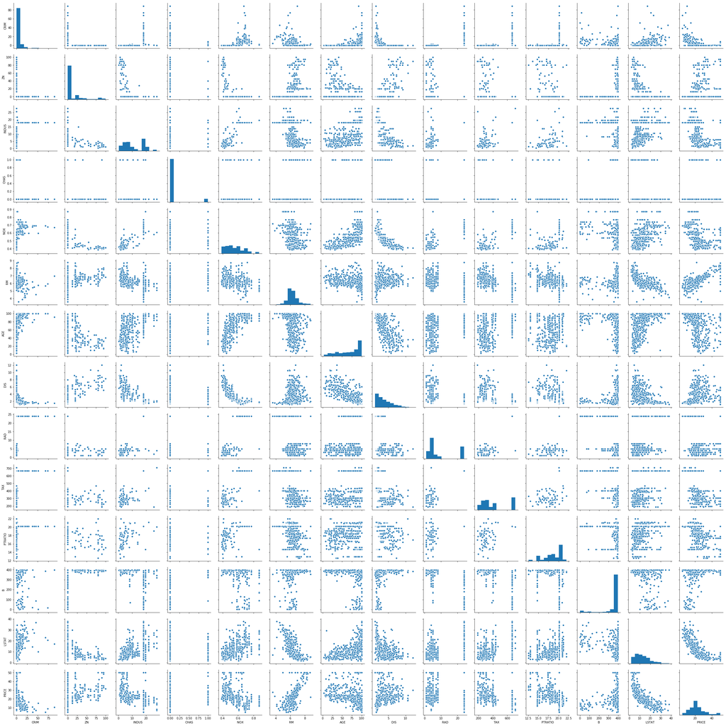

```python
sns.pairplot(boston_df)
```

# Question

### 想分析 iris 這組資料。根據前幾堂課學到的方法做一些，先來探索一下這組資料吧！

# Datasets -- Iris

Data Prepare

```python
iris_df = pd.DataFrame( iris.data )
iris_df.columns = iris.feature_names
iris_df['species'] = iris.target_names[iris.target]
```

確認資料維度

```python
iris_df.shape
```

```
(150, 5)
```

# Datasets -- Iris

可以利用前五筆資料，來看一下資料狀況

```python
iris_df.head()
```

|  | sepal length (cm) | sepal width (cm) | petal length (cm) | petal width (cm) | species |
| --- | --- | --- | --- | --- | --- |
| 0 | 5.1 | 3.5 | 1.4 | 0.2 | setosa |
| 1 | 4.9 | 3.0 | 1.4 | 0.2 | setosa |
| 2 | 4.7 | 3.2 | 1.3 | 0.2 | setosa |
| 3 | 4.6 | 3.1 | 1.5 | 0.2 | setosa |
| 4 | 5.0 | 3.6 | 1.4 | 0.2 | setosa |

# Datasets -- Iris

確認資料中是否有遺失值

```python
iris_df.isnull().sum()
```

```
sepal length (cm)    0
sepal width (cm)     0
petal length (cm)    0
petal width (cm)     0
species              0
dtype: int64
```

# Datasets -- Iris

基本敘述統計

```python
iris_df.describe()
```

|  | sepal length (cm) | sepal width (cm) | petal length (cm) | petal width (cm) |
| --- | --- | --- | --- | --- |
| count | 150.000000 | 150.000000 | 150.000000 | 150.000000 |
| mean | 5.843333 | 3.054000 | 3.758667 | 1.198667 |
| std | 0.828066 | 0.433594 | 1.764420 | 0.763161 |
| min | 4.300000 | 2.000000 | 1.000000 | 0.100000 |
| 25% | 5.100000 | 2.800000 | 1.600000 | 0.300000 |
| 50% | 5.800000 | 3.000000 | 4.350000 | 1.300000 |
| 75% | 6.400000 | 3.300000 | 5.100000 | 1.800000 |
| max | 7.900000 | 4.400000 | 6.900000 | 2.500000 |

```python
iris_df["species"].value_counts()
```

```
setosa        50
versicolor    50
virginica     50
Name: species, dtype: int64
```

# Datasets -- Iris

探索型資料視覺化

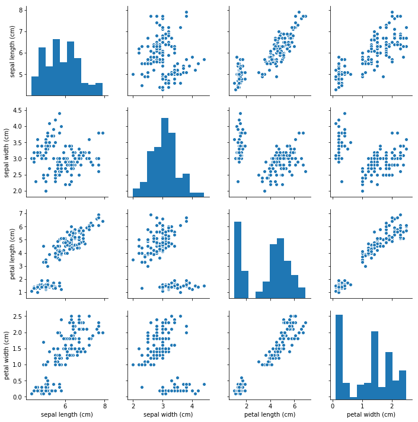

```python
sns.pairplot(iris_df)
```

# Datasets -- Iris

探索型資料視覺化

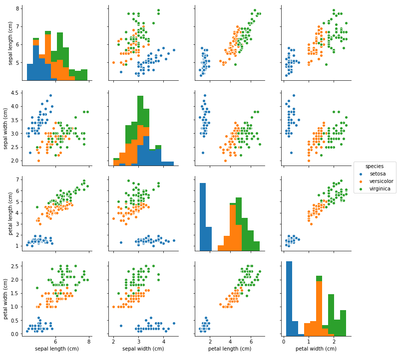

```python
sns.pairplot(iris_df ,hue='species')
```

# Datasets -- Iris

探索型資料視覺化

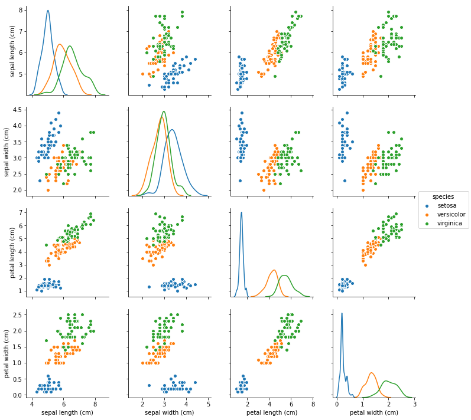

```python
sns.pairplot(iris_df ,hue='species',diag_kind="kde")
```

# Datasets -- Iris

探索型資料視覺化

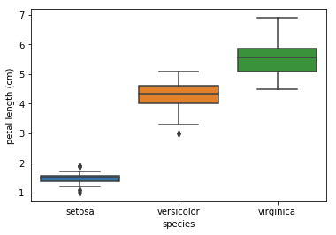

```python
sns.boxplot(x="species", y="petal length (cm)", data=iris_df)
```

# Scikit-Learn

### Train data ＆ Test data

# Train data ＆ Test data

#### Different version

```
from sklearn.model_selection import train_test_split
```

```
from sklearn.cross_validation import train_test_split
```

# Train data ＆ Test data

[figure not shown]

# Train data ＆ Test data

[figure not shown]

# Train data ＆ Test data

[figure not shown]

# Train data ＆ Test data

[figure not shown]

# Train data ＆ Test data -- Boston

Choose Data

```python
B_X = boston_df.drop('PRICE',axis=1)
B_y = boston_df['PRICE']
```

# Train data ＆ Test data -- Boston

Training and testing

```python
from sklearn.model_selection import train_test_split
```

```python
B_X_train, B_X_test, B_y_train, B_y_test = train_test_split(B_X , B_y , test_size = 0.2, random_state = 0)
```

# Train data ＆ Test data -- Iris

Choose Data

```python
I_X = iris_df.loc[:, ['petal length (cm)','petal width (cm)']]
I_y = iris.target
```

# Train data ＆ Test data -- Iris

Training and testing

```python
from sklearn.model_selection import train_test_split
```

```python
I_X_train, I_X_test, I_y_train, I_y_test = train_test_split(I_X, I_y, test_size = 0.3, random_state = 0)
```

# Scikit-Learn

### Machine Learning Algorithms -- Supervised learning

# Machine Learning Algorithms -- Supervised learning

- Regression
  - Linear Regression
  - Support Vector Regression
- Classification
  - Logistic Regression
  - K-Nearest Neighbors
  - Support Vector Machine

# Machine Learning Algorithms -- Supervised learning

## Linear Regression

[figure not shown]

> Reference : http://www.csie.ntnu.edu.tw/~u91029/Regression.html

# Machine Learning Algorithms -- Supervised learning

## Linear Regression

#### Import module

```python
from sklearn.linear_model import LinearRegression
```

#### Use LinearRegression

```python
lm = LinearRegression()
```

# Machine Learning Algorithms -- Supervised learning

## Linear Regression

#### Fit Model ( Training Data )

```python
lm.fit( B_X_train.values, B_y_train.values )
```

```
LinearRegression(copy_X=True, fit_intercept=True, n_jobs=1, normalize=False)
```

# Machine Learning Algorithms -- Supervised learning

## Linear Regression

#### Training Model ( Intercept )

```python
print(lm.intercept_)
```

```
38.1386927134
```

#### Training Model ( coefficient )

```python
print(lm.coef_)
```

```
[ -1.18410318e-01   4.47550643e-02   5.85674689e-03   2.34230117e+00
  -1.61634024e+01   3.70135143e+00  -3.04553661e-03  -1.38664542e+00
   2.43784171e-01  -1.09856157e-02  -1.04699133e+00   8.22014729e-03
  -4.93642452e-01]
```

# Machine Learning Algorithms -- Supervised learning

## Linear Regression

## Note

#### Training Model ( features and coefficients )

```python
pd.DataFrame(list( zip(B_X_train.columns,lm.coef_) ),columns=['features','estimatedCoeffs'])
```

|  | features | estimatedCoeffs |
| --- | --- | --- |
| 0 | CRIM | -0.118410 |
| 1 | ZN | 0.044755 |
| 2 | INDUS | 0.005857 |
| 3 | CHAS | 2.342301 |
| 4 | NOX | -16.163402 |
| 5 | RM | 3.701351 |
| 6 | AGE | -0.003046 |
| 7 | DIS | -1.386645 |
| 8 | RAD | 0.243784 |
| 9 | TAX | -0.010986 |
| 10 | PTRATIO | -1.046991 |
| 11 | B | 0.008220 |
| 12 | LSTAT | -0.493642 |

# Machine Learning Algorithms -- Supervised learning

## Linear Regression

#### Feature Test ( 係數檢定 )

```python
from sklearn.feature_selection import f_regression
print(f_regression(B_X_train, B_y_train)[1])
```

```
[  1.24951397e-17   8.53455987e-18   5.27647041e-30   3.33700835e-04
   1.67294465e-22   5.64340813e-62   4.20176291e-18   9.08403584e-09
   3.66673466e-19   2.94014039e-28   3.07127177e-35   2.18386516e-13
   6.88510971e-76]
```

## Note

##### 小數位數

```python
print(f_regression(B_X_train, B_y_train)[1].round(decimals=5))
```

```
[ 0.       0.       0.       0.00033  0.       0.       0.       0.       0.
  0.       0.       0.       0.     ]
```

# Machine Learning Algorithms -- Supervised learning

## Linear Regression

#### Predict (Test Data)

```python
B_y_predict = lm.predict(B_X_test)
```

```python
pd.DataFrame( list(zip(B_y_test.values,B_y_predict)), columns=['Measured','Predicted'] )
```

|  | Measured | Predicted |
| --- | --- | --- |
| 0 | 22.6 | 24.890130 |
| 1 | 50.0 | 23.724882 |
| 2 | 23.0 | 29.372133 |
| 3 | 8.3 | 12.140103 |
| 4 | 21.2 | 21.446865 |
| 5 | 19.9 | 19.286453 |
| 6 | 20.6 | 20.496373 |
| 7 | 18.7 | 21.361896 |
| 8 | 16.1 | 18.901879 |
| 9 | 18.6 | 19.892403 |
| 10 | 8.8 | 5.148872 |
| 11 | 17.2 | 16.346841 |
| 12 | 14.9 | 17.060125 |
| 13 | 10.5 | 5.609031 |
| 14 | 50.0 | 40.004621 |
| 15 | 29.0 | 32.494273 |
| 16 | 23.0 | 22.460817 |
| 17 | 33.3 | 36.855865 |
| 18 | 29.4 | 30.865793 |
| 19 | 21.0 | 23.154780 |
| 20 | 23.8 | 24.776560 |
| 21 | 19.1 | 24.679962 |
| 22 | 20.4 | 20.593782 |
| 23 | 29.1 | 30.356250 |
| 24 | 19.3 | 22.426400 |
| 25 | 23.1 | 10.228738 |
| 26 | 19.6 | 17.648142 |
| 27 | 19.4 | 18.260385 |
| 28 | 38.7 | 35.530774 |
| 29 | 18.7 | 20.961253 |
| ... | ... | ... |
| 72 | 23.5 | 30.734731 |
| 73 | 31.2 | 28.828630 |
| 74 | 23.7 | 25.901463 |
| 75 | 7.4 | 5.239417 |
| 76 | 48.3 | 36.712836 |
| 77 | 24.4 | 23.774485 |
| 78 | 22.6 | 27.271346 |
| 79 | 18.3 | 19.294855 |
| 80 | 23.3 | 28.624284 |
| 81 | 17.1 | 19.178398 |
| 82 | 27.9 | 18.975513 |
| 83 | 44.8 | 37.816238 |
| 84 | 50.0 | 39.208833 |
| 85 | 23.0 | 23.714100 |
| 86 | 21.4 | 24.934828 |
| 87 | 10.2 | 15.850637 |
| 88 | 23.3 | 26.096484 |
| 89 | 23.2 | 16.677999 |
| 90 | 18.9 | 15.833155 |
| 91 | 13.4 | 13.065319 |
| 92 | 21.9 | 24.722807 |
| 93 | 24.8 | 31.254435 |
| 94 | 11.9 | 22.171410 |
| 95 | 24.3 | 20.251676 |
| 96 | 13.8 | 0.596340 |
| 97 | 24.7 | 25.445216 |
| 98 | 14.1 | 15.521760 |
| 99 | 18.7 | 17.937782 |
| 100 | 28.1 | 25.306178 |
| 101 | 19.8 | 22.372220 |

102 rows × 2 columns

# Machine Learning Algorithms -- Supervised learning

## Linear Regression

#### Plot

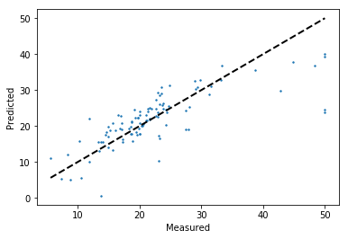

```python
plt.scatter(B_y_test.values,B_y_predict,s=2)
plt.plot([B_y_test.values.min(), B_y_test.values.max()], [B_y_test.values.min(), B_y_test.values.max()], 'k--', lw=2)
plt.ylabel('Predicted')
plt.xlabel('Measured')
```

# Machine Learning Algorithms -- Supervised learning

## Linear Regression

#### Model Performance

- Mean squared error（MSE）

```python
from sklearn.metrics import mean_squared_error
mse = mean_squared_error(B_y_test.values, B_y_predict)
print("MSE : ",mse)
```

```
MSE :  33.4507089677
```

# Machine Learning Algorithms -- Supervised learning

## Linear Regression

#### Model Performance

- R-squared

```python
R_2 = lm.score(B_X_train, B_y_train)
print("R-squared  : ",R_2)
```

```
R-squared  :  0.772971872657
```

- Adjusted R-squared

```python
adj_R_2 = R_2 - (1 - R_2) * (B_X_train.shape[1] / (B_X_train.shape[0] - B_X_train.shape[1] - 1))
print("Adjusted R-squared : ",adj_R_2)
```

```
Adjusted R-squared :  0.765404268412
```

# Machine Learning Algorithms -- Supervised learning

## Support Vector Regression ( SVR )

[figure not shown]

> Reference : https://www.mathworks.com/matlabcentral/fileexchange/43429-support-vector-regressiontml

# Machine Learning Algorithms -- Supervised learning

## Support Vector Regression ( SVR )

#### Import module

```python
from sklearn.svm import SVR
```

#### Use Support Vector Regression

```python
svr = SVR(kernel='rbf')
```

> rbf : 高斯徑向基底函數

# Machine Learning Algorithms -- Supervised learning

## Support Vector Regression ( SVR )

#### Training Model

```python
svr.fit( B_X_train.values, B_y_train.values )
```

```
SVR(C=1.0, cache_size=200, coef0=0.0, degree=3, epsilon=0.1, gamma='auto',
  kernel='rbf', max_iter=-1, shrinking=True, tol=0.001, verbose=False)
```

# Machine Learning Algorithms -- Supervised learning

## Support Vector Regression ( SVR )

#### Predict (Test Data)

```python
B_y_predict_svr = svr.predict(B_X_test)
```

```python
pd.DataFrame( list(zip(B_y_test.values,B_y_predict_svr)), columns=['Measured','Predicted'] )
```

|  | Measured | Predicted |
| --- | --- | --- |
| 0 | 22.6 | 21.360372 |
| 1 | 50.0 | 21.360428 |
| 2 | 23.0 | 21.375869 |
| 3 | 8.3 | 21.088170 |
| 4 | 21.2 | 21.357921 |
| 5 | 19.9 | 21.294222 |
| 6 | 20.6 | 21.318502 |
| 7 | 18.7 | 20.856544 |
| 8 | 16.1 | 21.360407 |
| 9 | 18.6 | 21.360407 |
| 10 | 8.8 | 21.360407 |
| 11 | 17.2 | 21.360209 |
| 12 | 14.9 | 20.876751 |
| 13 | 10.5 | 21.304793 |
| 14 | 50.0 | 21.541168 |
| 15 | 29.0 | 21.360566 |
| 16 | 23.0 | 21.360436 |
| 17 | 33.3 | 21.389027 |
| 18 | 29.4 | 21.360408 |
| 19 | 21.0 | 21.414940 |
| 20 | 23.8 | 21.471958 |
| 21 | 19.1 | 21.346785 |
| 22 | 20.4 | 21.314222 |
| 23 | 29.1 | 21.709732 |
| 24 | 19.3 | 21.360222 |
| 25 | 23.1 | 21.360407 |
| 26 | 19.6 | 21.224352 |
| 27 | 19.4 | 21.360407 |
| 28 | 38.7 | 21.362649 |
| 29 | 18.7 | 20.928249 |
| ... | ... | ... |
| 72 | 23.5 | 21.360420 |
| 73 | 31.2 | 21.360407 |
| 74 | 23.7 | 21.851062 |
| 75 | 7.4 | 21.360025 |
| 76 | 48.3 | 21.388638 |
| 77 | 24.4 | 21.423946 |
| 78 | 22.6 | 21.438740 |
| 79 | 18.3 | 20.909480 |
| 80 | 23.3 | 21.360407 |
| 81 | 17.1 | 18.860371 |
| 82 | 27.9 | 21.360405 |
| 83 | 44.8 | 21.501592 |
| 84 | 50.0 | 21.395877 |
| 85 | 23.0 | 21.367203 |
| 86 | 21.4 | 21.353663 |
| 87 | 10.2 | 21.360407 |
| 88 | 23.3 | 21.673876 |
| 89 | 23.2 | 21.360377 |
| 90 | 18.9 | 21.360407 |
| 91 | 13.4 | 21.360402 |
| 92 | 21.9 | 21.360407 |
| 93 | 24.8 | 21.360407 |
| 94 | 11.9 | 21.200132 |
| 95 | 24.3 | 21.360407 |
| 96 | 13.8 | 21.343289 |
| 97 | 24.7 | 21.360407 |
| 98 | 14.1 | 21.360405 |
| 99 | 18.7 | 21.379847 |
| 100 | 28.1 | 21.361395 |
| 101 | 19.8 | 21.121805 |

102 rows × 2 columns

# Machine Learning Algorithms -- Supervised learning

## Support Vector Regression ( SVR )

#### Plot

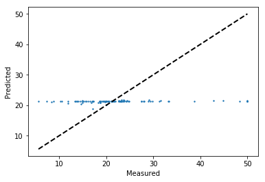

```python
plt.scatter(B_y_test.values,B_y_predict_svr,s=2)
plt.plot([B_y_test.values.min(), B_y_test.values.max()], [B_y_test.values.min(), B_y_test.values.max()], 'k--', lw=2)
plt.ylabel('Predicted')
plt.xlabel('Measured')
```

# Machine Learning Algorithms -- Supervised learning

## Support Vector Regression ( SVR )

## Question

### WHY ??

# Machine Learning Algorithms -- Supervised learning

## Support Vector Regression ( SVR )

## 資料標準化

```python
from sklearn.preprocessing import StandardScaler
```

```python
scaler = StandardScaler()
scaler.fit(B_X_train)
B_X_train_s = scaler.transform(B_X_train)
B_X_test_s = scaler.transform(B_X_test)
```

# Machine Learning Algorithms -- Supervised learning

## Support Vector Regression ( SVR )

```python
svr.fit( B_X_train_s, B_y_train.values )
```

```
SVR(C=1.0, cache_size=200, coef0=0.0, degree=3, epsilon=0.1, gamma='auto',
  kernel='rbf', max_iter=-1, shrinking=True, tol=0.001, verbose=False)
```

```python
B_y_predict_svr_s = svr.predict(B_X_test_s)
```

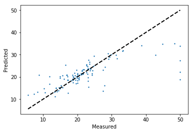

```python
plt.scatter(B_y_test.values,B_y_predict_svr_s,s=2)
plt.plot([B_y_test.values.min(), B_y_test.values.max()], [B_y_test.values.min(), B_y_test.values.max()], 'k--', lw=2)
plt.ylabel('Predicted')
plt.xlabel('Measured')
```

# Scikit-Learn

### Data Preprocessing

# Data Preprocessing

- StandardScaler $$ \acute{x} = \frac{x - \bar{x}}{\sigma} $$
- MinMaxScaler $$ \acute{x} = \frac{x - min(x)}{max(x) - min(x)} $$
- Normalizer $$ \acute{x} = \frac{x}{\lVert x \rVert} $$

# Data Preprocessing

## Note

#### 不要顯示科學計算符號，規定顯示小數五位

```python
np.set_printoptions(precision = 5, suppress = True)
```

# Data Preprocessing

#### Original

- Features : Petal length , Petal width
- Species : setosa , versicolor , virginica

```python
print("Mean : ",I_X.values.mean(axis=0))
print("Std : ",I_X.values.std(axis=0))
print("Max : ",I_X.values.max(axis=0))
print("Min : ",I_X.values.min(axis=0))
```

```
Mean :  [ 3.75867  1.19867]
Std :  [ 1.75853  0.76061]
Max :  [ 6.9  2.5]
Min :  [ 1.   0.1]
```

# Data Preprocessing

```python
from sklearn import preprocessing
```

# Data Preprocessing

#### StandardScaler

> z-score normalization

```python
standard = preprocessing.StandardScaler()
standard.fit(I_X)
I_X_s = standard.transform(I_X)
```

```python
print("Mean : ",I_X_s.mean(axis=0))
print("Std : ",I_X_s.std(axis=0))
print("Max : ",I_X_s.max(axis=0))
print("Min : ",I_X_s.min(axis=0))
```

```
Mean :  [-0. -0.]
Std :  [ 1.  1.]
Max :  [ 1.78634  1.7109 ]
Min :  [-1.56874 -1.44445]
```

# Data Preprocessing

#### MinMaxScaler

```python
minmax = preprocessing.MinMaxScaler()
minmax.fit(I_X)
I_X_m = minmax.transform(I_X)
```

```python
print("Mean : ",I_X_m.mean(axis=0))
print("Std : ",I_X_m.std(axis=0))
print("Max : ",I_X_m.max(axis=0))
print("Min : ",I_X_m.min(axis=0))
```

```
Mean :  [ 0.46757  0.45778]
Std :  [ 0.29806  0.31692]
Max :  [ 1.  1.]
Min :  [ 0.  0.]
```

# Data Preprocessing

#### Normalizer

```python
normal = preprocessing.Normalizer()
normal.fit(I_X)
I_X_n = normal.transform(I_X)
```

```python
print("Mean : ",I_X_n.mean(axis=0))
print("Std : ",I_X_n.std(axis=0))
print("Max : ",I_X_n.max(axis=0))
print("Min : ",I_X_n.min(axis=0))
```

```
Mean :  [ 0.95911  0.26772]
Std :  [ 0.02265  0.08904]
Max :  [ 0.99779  0.4258 ]
Min :  [ 0.90482  0.06652]
```

# Scikit-Learn

### Machine Learning Algorithms -- Supervised learning

# Machine Learning Algorithms -- Supervised learning

- Regression
  - Linear Regression
  - Support Vector Regression
- Classification
  - Logistic Regression
  - K-Nearest Neighbors
  - Support Vector Machine

# Machine Learning Algorithms -- Supervised learning

## Logistic Regression

[figure not shown]

> Reference : https://houxianxu.github.io/2015/04/23/logistic-softmax-regression

# Machine Learning Algorithms -- Supervised learning

## Logistic Regression

- Sigmoid Function

[figure not shown]

> Reference : http://www.saedsayad.com/logistic_regression.htm

# Machine Learning Algorithms -- Supervised learning

## Logistic Regression

- Sigmoid Function

## Note

```python
def SigmoidFunc(x):
    return 1 / (1 + np.exp(-x))
```

# Machine Learning Algorithms -- Supervised learning

## Logistic Regression

- Sigmoid Function

## Note

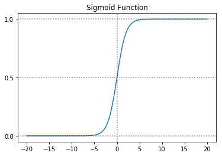

```python
Sigmoid_x = np.arange(-20, 20, 0.01)
Sigmoid_y = SigmoidFunc(Sigmoid_x)
plt.plot(Sigmoid_x, Sigmoid_y)
plt.axvline(0, ls='dotted', color='black', alpha=0.5)
plt.axhline(y=0, ls='dotted', color='black', alpha=0.5)
plt.axhline(y=0.5, ls = 'dotted', color='black', alpha=0.5)
plt.axhline(y=1, ls='dotted', color='black', alpha=0.5)
plt.yticks([0.0, 0.5, 1.0])
plt.ylim(-0.05, 1.05)
plt.title("Sigmoid Function")
plt.show()
```

# Machine Learning Algorithms -- Supervised learning

## Logistic Regression

- Multiclass classification

[figure not shown]

> Reference : https://houxianxu.github.io/2015/04/23/logistic-softmax-regression/

# Machine Learning Algorithms -- Supervised learning

## Logistic Regression

#### Import module

```python
from sklearn.linear_model import LogisticRegression
```

#### Use LogisticRegression

```python
logit = LogisticRegression()
```

# Machine Learning Algorithms -- Supervised learning

## Logistic Regression

#### Fit Model ( Training Data )

```python
logit.fit( I_X_train, I_y_train )
```

```
LogisticRegression(C=1.0, class_weight=None, dual=False, fit_intercept=True,
          intercept_scaling=1, max_iter=100, multi_class='ovr', n_jobs=1,
          penalty='l2', random_state=None, solver='liblinear', tol=0.0001,
          verbose=0, warm_start=False)
```

# Machine Learning Algorithms -- Supervised learning

## Logistic Regression

#### Predicting Species

```python
y_logit_predict = logit.predict( I_X_test )
```

> Compare Predict Value and Measure Value

```python
pd.DataFrame( list(zip( I_y_test, y_logit_predict)), columns=['Measured','Predicted'] )
```

|  | Measured | Predicted |
| --- | --- | --- |
| 0 | 2 | 2 |
| 1 | 1 | 1 |
| 2 | 0 | 0 |
| 3 | 2 | 2 |
| 4 | 0 | 0 |
| 5 | 2 | 2 |
| 6 | 0 | 0 |
| 7 | 1 | 2 |
| 8 | 1 | 2 |
| 9 | 1 | 2 |
| 10 | 2 | 1 |
| 11 | 1 | 2 |
| 12 | 1 | 1 |
| 13 | 1 | 2 |
| 14 | 1 | 2 |
| 15 | 0 | 0 |
| 16 | 1 | 2 |
| 17 | 1 | 1 |
| 18 | 0 | 0 |
| 19 | 0 | 0 |
| 20 | 2 | 2 |
| 21 | 1 | 2 |
| 22 | 0 | 0 |
| 23 | 0 | 0 |
| 24 | 2 | 2 |
| 25 | 0 | 0 |
| 26 | 0 | 0 |
| 27 | 1 | 2 |
| 28 | 1 | 1 |
| 29 | 0 | 0 |
| 30 | 2 | 2 |
| 31 | 1 | 2 |
| 32 | 0 | 0 |
| 33 | 2 | 2 |
| 34 | 2 | 2 |
| 35 | 1 | 2 |
| 36 | 0 | 0 |
| 37 | 1 | 2 |
| 38 | 1 | 2 |
| 39 | 1 | 1 |
| 40 | 2 | 2 |
| 41 | 0 | 0 |
| 42 | 2 | 2 |
| 43 | 0 | 0 |
| 44 | 0 | 0 |

# Machine Learning Algorithms -- Supervised learning

## Logistic Regression

> Compare Predict Value and Measure Value

```python
pd.DataFrame( list(zip(iris.target_names[ I_y_test],
                       iris.target_names[ y_logit_predict])), columns=['Measured','Predicted'] )
```

|  | Measured | Predicted |
| --- | --- | --- |
| 0 | virginica | virginica |
| 1 | versicolor | versicolor |
| 2 | setosa | setosa |
| 3 | virginica | virginica |
| 4 | setosa | setosa |
| 5 | virginica | virginica |
| 6 | setosa | setosa |
| 7 | versicolor | virginica |
| 8 | versicolor | virginica |
| 9 | versicolor | virginica |
| 10 | virginica | versicolor |
| 11 | versicolor | virginica |
| 12 | versicolor | versicolor |
| 13 | versicolor | virginica |
| 14 | versicolor | virginica |
| 15 | setosa | setosa |
| 16 | versicolor | virginica |
| 17 | versicolor | versicolor |
| 18 | setosa | setosa |
| 19 | setosa | setosa |
| 20 | virginica | virginica |
| 21 | versicolor | virginica |
| 22 | setosa | setosa |
| 23 | setosa | setosa |
| 24 | virginica | virginica |
| 25 | setosa | setosa |
| 26 | setosa | setosa |
| 27 | versicolor | virginica |
| 28 | versicolor | versicolor |
| 29 | setosa | setosa |
| 30 | virginica | virginica |
| 31 | versicolor | virginica |
| 32 | setosa | setosa |
| 33 | virginica | virginica |
| 34 | virginica | virginica |
| 35 | versicolor | virginica |
| 36 | setosa | setosa |
| 37 | versicolor | virginica |
| 38 | versicolor | virginica |
| 39 | versicolor | versicolor |
| 40 | virginica | virginica |
| 41 | setosa | setosa |
| 42 | virginica | virginica |
| 43 | setosa | setosa |
| 44 | setosa | setosa |

# Machine Learning Algorithms -- Supervised learning

## Logistic Regression

#### Check probability

```python
print(iris.target_names)
print(logit.predict_proba( I_X_test.iloc[0, :].values.reshape(1, 2)))
print(logit.predict_proba( I_X_test.iloc[1, :].values.reshape(1, 2)))
print(logit.predict_proba( I_X_test.iloc[2, :].values.reshape(1, 2)))
```

```
['setosa' 'versicolor' 'virginica']
[[ 0.00368  0.20336  0.79297]]
[[ 0.14155  0.53555  0.3229 ]]
[[ 0.72601  0.23859  0.0354 ]]
```

# Machine Learning Algorithms -- Supervised learning

## Logistic Regression

#### Check probability

## Note

[figure not shown]

# Machine Learning Algorithms -- Supervised learning

## Logistic Regression

#### Accuracy

```python
from sklearn.metrics import accuracy_score
print('Accuracy:',accuracy_score( I_y_test, y_logit_predict))
```

```
Accuracy: 0.688888888889
```

## Note

## Decision boundary

```python
from matplotlib.colors import ListedColormap
def DecisionBoundary_plot(X, y, method, h=.02):
    markers = ('o', '*', '^')
    colors = ('yellow', 'magenta', 'cyan')
    colormap = ListedColormap(colors[:len(np.unique(y))])

    x_min, x_max = X[:,0].min()-1, X[:,0].max()+1
    y_min, y_max = X[:,1].min()-1, X[:,1].max()+1
    xx, yy = np.meshgrid(np.arange(x_min, x_max, h),
                         np.arange(y_min, y_max, h))
    Z = method.predict(np.array([xx.ravel(), yy.ravel()]).T)
    Z = Z.reshape(xx.shape)
    plt.contourf(xx, yy, Z, alpha=0.2, cmap=colormap)
    plt.xlim(xx.min(), xx.max())
    plt.ylim(yy.min(), yy.max())
    for ix, lab in enumerate(np.unique(y)):
        spec = iris.target_names[lab]
        plt.scatter( x = X[y==lab,0], y = X[y==lab,1],
                     c=colormap(ix), marker=markers[ix], label=spec)
```

# Machine Learning Algorithms -- Supervised learning

## Logistic Regression

#### Plot ( Decision boundary )

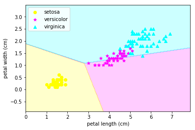

```python
DecisionBoundary_plot(X= I_X.values, y= I_y, method=logit)
plt.xlabel('petal length (cm)')
plt.ylabel('petal width (cm)')
plt.legend(loc = 'upper left')
plt.show()
```

# Question

### 利用經過 StandardScaler 轉換後的資料，建立Logistic Regression Model，並比較 Accuracy

# Logistic Regression Model -- StandardScaler Data

Data Prepare -- Training and testing

```python
I_X_train_s, I_X_test_s, I_y_train_s, I_y_test_s = train_test_split( I_X_s, I_y, test_size = 0.3, random_state = 0)
```

Model

```python
logit_s = LogisticRegression()
logit_s.fit( I_X_train_s, I_y_train_s )
```

```
LogisticRegression(C=1.0, class_weight=None, dual=False, fit_intercept=True,
          intercept_scaling=1, max_iter=100, multi_class='ovr', n_jobs=1,
          penalty='l2', random_state=None, solver='liblinear', tol=0.0001,
          verbose=0, warm_start=False)
```

# Logistic Regression Model -- StandardScaler Data

Predict

```python
y_logit_predict_s = logit_s.predict( I_X_test_s )
```

Accuracy

```python
print('Accuracy(Standard):',accuracy_score( I_y_test_s, y_logit_predict_s))
```

```
Accuracy(Standard): 0.8
```

> 經過標準化的資料， Accuracy 更好

# Logistic Regression Model -- StandardScaler Data

Plot ( Decision boundary )

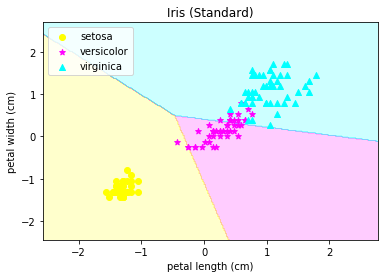

```python
DecisionBoundary_plot(X= I_X_s, y= I_y, method=logit_s)
plt.title('Iris (Standard)')
plt.xlabel('petal length (cm)')
plt.ylabel('petal width (cm)')
plt.legend(loc = 'upper left')
plt.show()
```

## Note

## Linear VS Nonlinear

[figure not shown]

> Reference : https://sebastianraschka.com/Articles/2014_kernel_pca.html

## Note

## Classification of linearly nonseparable

- K-nearest neighbor (KNN)
- Support Vector Machine (SVM)
- Decision Tree

# Machine Learning Algorithms -- Supervised learning

## K-Nearest Neighbors

- 找 K 個鄰居

[figure not shown]

> Reference : https://www.slideshare.net/ssuserf88631/knn-51511604

# Machine Learning Algorithms -- Supervised learning

## K-Nearest Neighbors

- 由鄰居決定類別

[figure not shown]

> Reference : https://www.slideshare.net/ssuserf88631/knn-51511604

# Machine Learning Algorithms -- Supervised learning

## K-Nearest Neighbors

#### Import module

```python
from sklearn.neighbors import KNeighborsClassifier
```

#### Use KNeighborsClassifier

```python
knn = KNeighborsClassifier()
```

# Machine Learning Algorithms -- Supervised learning

## K-Nearest Neighbors

#### Fit Model ( Training Data )

```python
knn.fit( I_X_train_s, I_y_train_s)
```

```
KNeighborsClassifier(algorithm='auto', leaf_size=30, metric='minkowski',
           metric_params=None, n_jobs=1, n_neighbors=5, p=2,
           weights='uniform')
```

# Machine Learning Algorithms -- Supervised learning

## K-Nearest Neighbors

#### Predicting Species

```python
y_knn_predict = knn.predict( I_X_test_s )
```

> Compare Predict Value and Measure Value

```python
pd.DataFrame( list(zip(iris.target_names[ I_y_test_s],
                       iris.target_names[ y_knn_predict])), columns=['Measured','Predicted'] )
```

|  | Measured | Predicted |
| --- | --- | --- |
| 0 | virginica | virginica |
| 1 | versicolor | versicolor |
| 2 | setosa | setosa |
| 3 | virginica | virginica |
| 4 | setosa | setosa |
| 5 | virginica | virginica |
| 6 | setosa | setosa |
| 7 | versicolor | versicolor |
| 8 | versicolor | versicolor |
| 9 | versicolor | versicolor |
| 10 | virginica | virginica |
| 11 | versicolor | versicolor |
| 12 | versicolor | versicolor |
| 13 | versicolor | versicolor |
| 14 | versicolor | versicolor |
| 15 | setosa | setosa |
| 16 | versicolor | versicolor |
| 17 | versicolor | versicolor |
| 18 | setosa | setosa |
| 19 | setosa | setosa |
| 20 | virginica | virginica |
| 21 | versicolor | versicolor |
| 22 | setosa | setosa |
| 23 | setosa | setosa |
| 24 | virginica | virginica |
| 25 | setosa | setosa |
| 26 | setosa | setosa |
| 27 | versicolor | versicolor |
| 28 | versicolor | versicolor |
| 29 | setosa | setosa |
| 30 | virginica | virginica |
| 31 | versicolor | versicolor |
| 32 | setosa | setosa |
| 33 | virginica | virginica |
| 34 | virginica | virginica |
| 35 | versicolor | versicolor |
| 36 | setosa | setosa |
| 37 | versicolor | versicolor |
| 38 | versicolor | versicolor |
| 39 | versicolor | versicolor |
| 40 | virginica | virginica |
| 41 | setosa | setosa |
| 42 | virginica | virginica |
| 43 | setosa | setosa |
| 44 | setosa | setosa |

# Machine Learning Algorithms -- Supervised learning

## K-Nearest Neighbors

#### Accuracy

```python
from sklearn.metrics import accuracy_score
print('Accuracy:',accuracy_score( I_y_test_s, y_knn_predict))
```

```
Accuracy: 1.0
```

# Machine Learning Algorithms -- Supervised learning

## K-Nearest Neighbors

#### Plot ( Decision boundary )

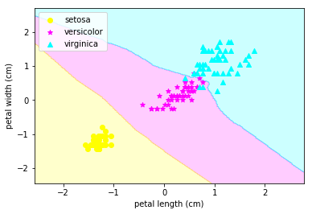

```python
DecisionBoundary_plot(X= I_X_s, y= I_y, method=knn)
plt.xlabel('petal length (cm)')
plt.ylabel('petal width (cm)')
plt.legend(loc = 'upper left')
plt.show()
```

# Machine Learning Algorithms -- Supervised learning

## Support Vector Machine ( SVM )

[figure not shown]

> Reference : https://www.linkedin.com/pulse/support-vector-machine-srinivas-kulkarni

## Note

## Support Vector Machine

- Radial basis function kernel $$ K( \, x,\acute{x} \, ) = exp(-\gamma \lVert x - \acute{x} \rVert^2 ) , where \, \gamma = \frac{1}{2 \sigma^2} $$

# Machine Learning Algorithms -- Supervised learning

## Support Vector Machine ( SVM )

#### Import module

```python
from sklearn.svm import SVC
```

#### Use SVC

```python
svm = SVC(kernel = 'rbf', random_state = 0, gamma = 0.2)
```

# Machine Learning Algorithms -- Supervised learning

## Support Vector Machine ( SVM )

#### Fit Model ( Training Data )

```python
svm.fit( I_X_train, I_y_train )
```

```
SVC(C=1.0, cache_size=200, class_weight=None, coef0=0.0,
  decision_function_shape='ovr', degree=3, gamma=0.2, kernel='rbf',
  max_iter=-1, probability=False, random_state=0, shrinking=True,
  tol=0.001, verbose=False)
```

# Machine Learning Algorithms -- Supervised learning

## Support Vector Machine ( SVM )

#### Predicting Species

```python
y_svm_predict = svm.predict( I_X_test )
```

> Compare Predict Value and Measure Value

```python
pd.DataFrame( list(zip(iris.target_names[ I_y_test],
                       iris.target_names[ y_svm_predict])), columns=['Measured','Predicted'] )
```

|  | Measured | Predicted |
| --- | --- | --- |
| 0 | virginica | virginica |
| 1 | versicolor | versicolor |
| 2 | setosa | setosa |
| 3 | virginica | virginica |
| 4 | setosa | setosa |
| 5 | virginica | virginica |
| 6 | setosa | setosa |
| 7 | versicolor | versicolor |
| 8 | versicolor | versicolor |
| 9 | versicolor | versicolor |
| 10 | virginica | virginica |
| 11 | versicolor | versicolor |
| 12 | versicolor | versicolor |
| 13 | versicolor | versicolor |
| 14 | versicolor | versicolor |
| 15 | setosa | setosa |
| 16 | versicolor | versicolor |
| 17 | versicolor | versicolor |
| 18 | setosa | setosa |
| 19 | setosa | setosa |
| 20 | virginica | virginica |
| 21 | versicolor | versicolor |
| 22 | setosa | setosa |
| 23 | setosa | setosa |
| 24 | virginica | virginica |
| 25 | setosa | setosa |
| 26 | setosa | setosa |
| 27 | versicolor | versicolor |
| 28 | versicolor | versicolor |
| 29 | setosa | setosa |
| 30 | virginica | virginica |
| 31 | versicolor | versicolor |
| 32 | setosa | setosa |
| 33 | virginica | virginica |
| 34 | virginica | virginica |
| 35 | versicolor | versicolor |
| 36 | setosa | setosa |
| 37 | versicolor | virginica |
| 38 | versicolor | versicolor |
| 39 | versicolor | versicolor |
| 40 | virginica | virginica |
| 41 | setosa | setosa |
| 42 | virginica | virginica |
| 43 | setosa | setosa |
| 44 | setosa | setosa |

# Machine Learning Algorithms -- Supervised learning

## Support Vector Machine ( SVM )

#### Accuracy

```python
from sklearn.metrics import accuracy_score
print('Accuracy:',accuracy_score( I_y_test, y_svm_predict))
```

```
Accuracy: 0.977777777778
```

# Machine Learning Algorithms -- Supervised learning

## Support Vector Machine ( SVM )

#### Plot ( Decision boundary )

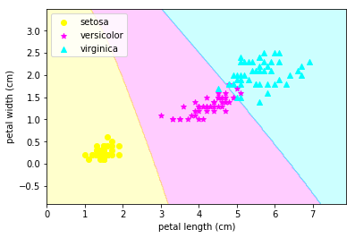

```python
DecisionBoundary_plot(X= I_X.values , y= I_y, method=svm)
plt.xlabel('petal length (cm)')
plt.ylabel('petal width (cm)')
plt.legend(loc = 'upper left')
plt.show()
```

# Question

### 利用經過 StandardScaler 轉換後的資料，建立SVM Model，並比較 Accuracy

# Support Vector Machine ( SVM ) Model -- StandardScaler Data

Data Prepare -- Training and testing

Model

```python
svm_s = SVC(kernel = 'rbf', random_state = 0, gamma = 0.2)
svm_s.fit( I_X_train_s, I_y_train_s )
```

```
SVC(C=1.0, cache_size=200, class_weight=None, coef0=0.0,
  decision_function_shape='ovr', degree=3, gamma=0.2, kernel='rbf',
  max_iter=-1, probability=False, random_state=0, shrinking=True,
  tol=0.001, verbose=False)
```

# Support Vector Machine ( SVM ) Model -- StandardScaler Data

Predict

```python
y_svm_predict_s = svm_s.predict( I_X_test_s )
```

Accuracy

```python
print('Accuracy:',accuracy_score( I_y_test_s, y_svm_predict_s))
```

```
Accuracy: 0.977777777778
```

# Support Vector Machine ( SVM ) Model -- StandardScaler Data

Plot ( Decision boundary )

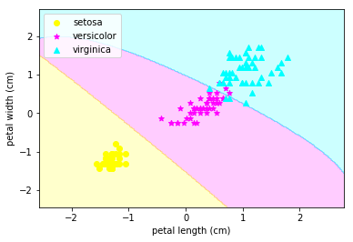

```python
DecisionBoundary_plot(X= I_X_s, y=I_y, method=svm_s)
plt.xlabel('petal length (cm)')
plt.ylabel('petal width (cm)')
plt.legend(loc = 'upper left')
plt.show()
```

## Note

## Overfitting

[figure not shown]

> Reference : http://mlwiki.org/index.php/Overfitting

# Scikit-Learn

### Machine Learning Algorithms -- Unsupervised learning

# Machine Learning Algorithms -- Unsupervised learning

- Unsupervised learning
  - K-means
  - Hierarchical clustering

# Machine Learning Algorithms -- Unsupervised learning

## K means

[figure not shown]

> Reference : : https://dotblogs.com.tw/dragon229/2013/02/04/89919

# Machine Learning Algorithms -- Unsupervised learning

## K means

[figure not shown]

> Reference : https://dotblogs.com.tw/dragon229/2013/02/04/89919

# Machine Learning Algorithms -- Unsupervised learning

## K means

[figure not shown]

> Reference : http://www.csie.ntnu.edu.tw/~u91029/Classification.html

# Machine Learning Algorithms -- Unsupervised learning

## K means

[figure not shown]

> Reference : http://www.csie.ntnu.edu.tw/~u91029/Classification.html

# Machine Learning Algorithms -- Unsupervised learning

## K means

[figure not shown]

> Reference : http://www.csie.ntnu.edu.tw/~u91029/Classification.html

# Machine Learning Algorithms -- Unsupervised learning

## K means

[figure not shown]

> Reference : http://www.csie.ntnu.edu.tw/~u91029/Classification.html

# Machine Learning Algorithms -- Unsupervised learning

## K means

[figure not shown]

> Reference : http://www.csie.ntnu.edu.tw/~u91029/Classification.html

# Machine Learning Algorithms -- Unsupervised learning

## K means

[figure not shown]

> Reference : http://www.csie.ntnu.edu.tw/~u91029/Classification.html

# Machine Learning Algorithms -- Unsupervised learning

## K means

#### Import module

```python
from sklearn.cluster import KMeans
```

#### Use KMeans

```python
kmeans = KMeans(n_clusters = 3)
```

# Machine Learning Algorithms -- Unsupervised learning

## K means

#### Fit Model

```python
kmeans_fit = kmeans.fit( I_X )
```

# Machine Learning Algorithms -- Unsupervised learning

## K means

#### Result

```python
kmeans_result = kmeans_fit.labels_
```

> Compare Original and Cluster

```python
pd.DataFrame( list(zip(iris.target_names[I_y],
                       iris.target_names[kmeans_result])), columns=['Original','Cluster'] )
```

|  | Original | Cluster |
| --- | --- | --- |
| 0 | setosa | setosa |
| 1 | setosa | setosa |
| 2 | setosa | setosa |
| 3 | setosa | setosa |
| 4 | setosa | setosa |
| 5 | setosa | setosa |
| 6 | setosa | setosa |
| 7 | setosa | setosa |
| 8 | setosa | setosa |
| 9 | setosa | setosa |
| 10 | setosa | setosa |
| 11 | setosa | setosa |
| 12 | setosa | setosa |
| 13 | setosa | setosa |
| 14 | setosa | setosa |
| 15 | setosa | setosa |
| 16 | setosa | setosa |
| 17 | setosa | setosa |
| 18 | setosa | setosa |
| 19 | setosa | setosa |
| 20 | setosa | setosa |
| 21 | setosa | setosa |
| 22 | setosa | setosa |
| 23 | setosa | setosa |
| 24 | setosa | setosa |
| 25 | setosa | setosa |
| 26 | setosa | setosa |
| 27 | setosa | setosa |
| 28 | setosa | setosa |
| 29 | setosa | setosa |
| ... | ... | ... |
| 120 | virginica | versicolor |
| 121 | virginica | versicolor |
| 122 | virginica | versicolor |
| 123 | virginica | versicolor |
| 124 | virginica | versicolor |
| 125 | virginica | versicolor |
| 126 | virginica | virginica |
| 127 | virginica | versicolor |
| 128 | virginica | versicolor |
| 129 | virginica | versicolor |
| 130 | virginica | versicolor |
| 131 | virginica | versicolor |
| 132 | virginica | versicolor |
| 133 | virginica | versicolor |
| 134 | virginica | versicolor |
| 135 | virginica | versicolor |
| 136 | virginica | versicolor |
| 137 | virginica | versicolor |
| 138 | virginica | virginica |
| 139 | virginica | versicolor |
| 140 | virginica | versicolor |
| 141 | virginica | versicolor |
| 142 | virginica | versicolor |
| 143 | virginica | versicolor |
| 144 | virginica | versicolor |
| 145 | virginica | versicolor |
| 146 | virginica | versicolor |
| 147 | virginica | versicolor |
| 148 | virginica | versicolor |
| 149 | virginica | versicolor |

150 rows × 2 columns

# Machine Learning Algorithms -- Unsupervised learning

## K means

#### Silhouette

```python
from sklearn.metrics import silhouette_score
print('Silhouette:',silhouette_score( I_X, kmeans_result))
```

```
Silhouette: 0.660276088219
```

> 分群演算法的績效可以使用 Silhouette 係數

# Question

### 利用經過 MinMaxScaler 轉換後的資料，做 K-Means Cluster，並比較 Silhouette

# K-MeansModel -- MinMaxScaler Data

Model

```python
kmeans_fit_m = kmeans.fit( I_X_m )
```

```python
kmeans_result_m = kmeans_fit_m.labels_
```

```python
print('Silhouette:',silhouette_score( I_X_m, kmeans_result_m ))
```

```
Silhouette: 0.675805601905
```

# Machine Learning Algorithms -- Unsupervised learning

## Hierarchical Clustering

- Tries to combine or divide a dataset into clusters
- A tree-like hierarchical structure is created
- Can adopt two approaches :
  - Agglomerative hierarchical clustering
  - Divisive hierarchical clustering

# Machine Learning Algorithms -- Unsupervised learning

## Hierarchical Clustering

[figure not shown]

> Reference : https://quantdare.com/hierarchical-clustering/

# Machine Learning Algorithms -- Unsupervised learning

## Hierarchical Clustering

[figure not shown]

> Reference : http://www.sthda.com/english/wiki/hierarchical-clustering-essentials-unsupervised-machine-learning/

# Machine Learning Algorithms -- Unsupervised learning

## Hierarchical Clustering

#### Import module

```python
from sklearn.cluster import AgglomerativeClustering
```

#### Use AgglomerativeClustering

```python
hierarchical = AgglomerativeClustering(linkage = 'ward', affinity = 'euclidean', n_clusters = 3)
```

# Machine Learning Algorithms -- Unsupervised learning

## Hierarchical Clustering

#### Fit Model

```python
hierarchical_fit = hierarchical.fit( I_X )
```

# Machine Learning Algorithms -- Unsupervised learning

## Hierarchical Clustering

#### Result

```python
hierarchical_result = hierarchical_fit.labels_
```

> Compare Original and Cluster

```python
pd.DataFrame( list(zip(iris.target_names[I_y],
                       iris.target_names[hierarchical_result])), columns=['Measured','Predicted'] )
```

|  | Measured | Predicted |
| --- | --- | --- |
| 0 | setosa | versicolor |
| 1 | setosa | versicolor |
| 2 | setosa | versicolor |
| 3 | setosa | versicolor |
| 4 | setosa | versicolor |
| 5 | setosa | versicolor |
| 6 | setosa | versicolor |
| 7 | setosa | versicolor |
| 8 | setosa | versicolor |
| 9 | setosa | versicolor |
| 10 | setosa | versicolor |
| 11 | setosa | versicolor |
| 12 | setosa | versicolor |
| 13 | setosa | versicolor |
| 14 | setosa | versicolor |
| 15 | setosa | versicolor |
| 16 | setosa | versicolor |
| 17 | setosa | versicolor |
| 18 | setosa | versicolor |
| 19 | setosa | versicolor |
| 20 | setosa | versicolor |
| 21 | setosa | versicolor |
| 22 | setosa | versicolor |
| 23 | setosa | versicolor |
| 24 | setosa | versicolor |
| 25 | setosa | versicolor |
| 26 | setosa | versicolor |
| 27 | setosa | versicolor |
| 28 | setosa | versicolor |
| 29 | setosa | versicolor |
| ... | ... | ... |
| 120 | virginica | setosa |
| 121 | virginica | setosa |
| 122 | virginica | setosa |
| 123 | virginica | setosa |
| 124 | virginica | setosa |
| 125 | virginica | setosa |
| 126 | virginica | setosa |
| 127 | virginica | setosa |
| 128 | virginica | setosa |
| 129 | virginica | setosa |
| 130 | virginica | setosa |
| 131 | virginica | setosa |
| 132 | virginica | setosa |
| 133 | virginica | setosa |
| 134 | virginica | setosa |
| 135 | virginica | setosa |
| 136 | virginica | setosa |
| 137 | virginica | setosa |
| 138 | virginica | setosa |
| 139 | virginica | setosa |
| 140 | virginica | setosa |
| 141 | virginica | setosa |
| 142 | virginica | setosa |
| 143 | virginica | setosa |
| 144 | virginica | setosa |
| 145 | virginica | setosa |
| 146 | virginica | setosa |
| 147 | virginica | setosa |
| 148 | virginica | setosa |
| 149 | virginica | setosa |

150 rows × 2 columns

# Machine Learning Algorithms -- Unsupervised learning

## Hierarchical Clustering

#### Silhouette

```python
from sklearn.metrics import silhouette_score
print('Silhouette:',silhouette_score( I_X, hierarchical_result))
```

```
Silhouette: 0.657185644873
```